# Sesión 1: Introducción básica

T. Evgeniou (adaptación: Eduardo Aguilar)

Este documento es una adaptación en español del [archivo original](http://inseaddataanalytics.github.io/INSEADAnalytics/CourseSessions/Session1/Session1inclass.html) del curso de INSEADanalytics.

**Nota:** Nuevamente, para que su computadora pueda leer tildes y caracteres no ingleses deberá guardar el archivo en File –> “Save witrh encoding”–> UTF-8 y después compilarlo.

Si usted quiere crear un archivo html puede hacerlo de dos formas: presionando el botón Knit o corriendo en la consola el comando *rmarkdown::render(“Intro_basica.Rmd”)*. Si tiene un error es posible que su directorio haya cambiado, en cuyo caso deberá ajustar los nombres de las carpetas.

El propósito de esta sesión es familiarizarse con:

1. Manejo de directorios en R;
2. Lectura/Escritura de información;
3. Uso de librerías
4. Estadísticas descriptivas;
5. Gráficas simples

Antes de empezar, asegúrese que ha descargado los archivos de la [sesión 1](https://github.com/conciclicboy/UCAanalytics/tree/master/Sesiones/Sesiones_1_2_Intro_R) en su repositorio de github (si descarga el repositorio del curso desde github usted también descarga las sesiones automáticamente). Para confirmar, usted también puede correr el archivo “update_fork.R” el cual se encuentra en el directorio principal del curso.

### 1. Manejo de directorios en R

Manejar los directorios puede ser una frustrante y continua fuente de problemas, por lo que se recomienda aprender esos comandos de R desde el inicio para encontrar cual es su directorio de trabajo actual y, si es necesario, cambiar el directorio donde usted lo necesita (donde tiene los archivos de la clase). Para encontrar el directorio donde está ubicado puede utilizar la función *getwd()* en la consola de R, o lo puede llamar desde un bloque de código:

```r
# Este comando muestra el directorio donde nos encontramos:

#getwd()
```

Notará que inicialmente, la ubicación del directorio es la carpeta donde está alojado este archivo, cuya estructura la cual puede consultar en [directorio sesión 1](https://github.com/conciclicboy/UCAanalytics/tree/master/Sesiones/Sesiones_1_2_Intro_R). Sin embargo, en ocasiones será importante cambiar la ubicación para acceder a información que esté en otras carpetas, lo cual es posible utilizando la función *setwd()*. Dentro de esa función escribirá la dirección donde desea ubicar el archivo. Ese cambio será permanente en un archivo R Script y temporal en un bloque de código de RMarkdown (solo cambiará mientras se encuentre en ese bloque de código, en el siguiente bloque regresará a la dirección inicial). El formato para escribir la ubicación debe ser igual al que obtuvo cuando ejecutó la función *setwd()*.

```r
# Este comando puede cambiar la ubicación del directorio si es necesario:

#setwd("PONGA AQUÍ LA NUEVA UBICACIÓN")
```

Y nuevamente, si usted vuelve a ejecutar la función *getwd()* la dirección habrá regresado al valor original, ya que el cambio se dió solamente dentro del bloque donde estaba ubicado.

```r
# OBTENGA LA DIRECCIÓN ACTUAL
```

### 2. Lectura de Información en R

Se preguntará para que sirve cambiar la dirección, pues bien, usted puede necesitar leer información de otros archivos de R o archivos de datos. Por ejemplo, usted puede importar la información que hay en un archivo de R utilizando la función *source()*. Intente llamar el archivo “library.R” que se encuentra en la carpeta *AnalyticsLibraries*:

```r
#setwd("PONGA AQUÍ LA UBICACIÓN")

#Llame la librería
#source("library.R")
```

**Añadiendo archivos** El directorio actual contiene carpetas, archivos .Rmd y .html. Todo lo que contiene (además de unos archivos de imágenes) es un archivo .Rmd, un .R y una carpeta donde guardamos los datos. Podemos crear carpetas nuevas usando la opción “New Folder”.

[figure not shown]

Cree un nuevo directorio adentro del folder “Sesiones/Sesiones_1_2_Intro_R/” (lo puede llamar “data”) y guarde el archivo Boats.csv de las sesiones 5-6 en la carpeta “data”.

Para leer datos en un archivo csv se puede usar la función *read.csv()*. Intente leer el documento que acaba de copiar en la carpeta data:

```r
#ProjectData <- read.csv(file = "NOMBRE DEL ARCHIVO", header = TRUE, sep=",")

ProjectData <- read.csv(file = "data/Boats.csv", header = TRUE, sep=",")
```

Veamos ahora que son estos datos. Corra los comandos para ver el número de filas, columnas, y los nombres de las filas y las columnas:

```r
# Cambie la parte donde dice r eval = FALSE por TRUE para poder ver los cambios en el documento HTML

# Número de filas en el archivo
ncol(ProjectData)

# Nombres de columnas
colnames(ProjectData)

# Nombres de las primeras 10 columans
colnames(ProjectData)[1:10]

# Ejecute esta línea bajo su propio riesgo pues tiene 2813 observaciones
#rownames(ProjectData)
```

De forma opuesta, también se pueden generar archivos csv con la función `write.csv` o con `save`.

### 3. Uso de librerías

Uno de los mayores beneficios de utilizar software libre es la impresionante disponibilidad de muchas funciones así como código que la gente desarrolla y comparte. Hay un rápido crecimiento de herramientas libres que se pueden utilizar incluso en sus trabajos, y así evitar reinventar la rueda para mejor subirse a la ola.

Hay muchas más formas de adquirir nuevas herramientas. Primero, las herramientas “maduras/probadas” están disponibles como paquetes que se pueden instalar en RStudio. Eche un vistazo aquí [lista de paquetes en R](https://cran.r-project.org/web/packages/available_packages_by_name.html) y vea cuales le gustan.

Para instalar un paquete en R de click en el menú “Packages”. En la barra de búsqueda escriba el nombre de la librería que desea instalar, de click en la casilla de la izquierda y presione el botón de *install*. Esto descargará de internet el paquete (por lo tanto usted necesita estar conectado). Usted puede después cargar la librería ya sea seleccionándolaen la lista de paquetes instalados utilizando el comando `library` en R, por ejemplo veamos la librería de modelación financiera `library("quantmod")`.

[figure not shown]

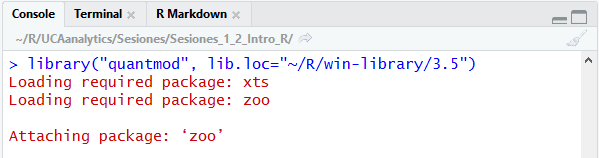

Usted también puede descargar paquetes directamente desde la consola de R, pero por facilidad se recomienda utilizar el menú Packages de RStudio. Para instalar una librería utilice la función *install.packages()* y coloque dentro del paréntesis el nombre del paquete que desea instalar

```r
#Instalandola manualmente
#install.packages("NOMBRE DE ALGUNA LIBRERIA QUE NO TENGA INSTALADA")

#Llamando la librería
#library(NOMBRE DE LA LIBRERÍA SIN COMILLAS)
```

Una vez se tiene la librería se puede dar click en el (en el menú “Packages”) para verificar los comandos disponibles (también disponible en la [lista de paquetes de R](https://cran.r-project.org/web/packages/available_packages_by_name.html), por ejemplo en este caso para [documentación de quantmod)](https://cran.r-project.org/web/packages/quantmod/quantmod.pdf). Usted puede entonce explorar- siempre buscando en internet el código ejemplo (por ej: para [ejemplos quantmod](https://www.quantmod.com/examples/) ).

```r
# Debe tener instalado quantmod antes de ejecutar este código
library(quantmod)

# Obteniendo una tabla de precios del stock de Apple con precios de yahoo finance
getSymbols("AAPL",src="yahoo")


# Si usted ejecuta el proceso anterior se debió haber generado un dataframe llamado AAPL que contiene 6 diferentes precios de la acción de Apple.
# Ahora puede utilizar la función "plot()" para graficar alguno de esos precios,

#plot(AAPL$AAPL.Open)
```

**Nota:** Algunas librerías podrían requerir que reinicie RStudio o instale otro software o o reinicie totalmente su computadora.

**Nota:** Hay maneras eficientes de instalar paquetes. Por ejemplo, uno puede usar algo como lo que usamos [en este código.](https://github.com/InseadDataAnalytics/INSEADAnalytics/blob/master/CourseSessions/Session1/library.R)

### Obteniendo código de Repositorios en Github

Un método alternativo para obtener código (y ver códigos de ejemplo - la mejor forma de aprender) es simplemente buscando en el vasto número de cuentas de github públicas. Por ejemplo, esta lista de [repositorios de moda](https://github.com/trending?l=R) (toma tiempo crearlas!) o incluso el [mismo código fuente de R](https://github.com/wch/r-source) o por supuesto links de muchos otros [recursos en R](http://www.r-bloggers.com/tag/github/). Bienvenido a este nuevo mundo!

#### Preguntas

1. ¿Ubíquese en la consula de R, y verifique si tiene disponibles los paquetes: `datasets`, `FactoMineR`,`png` y `stringr`. Intente instalar los que no tenga.
2. Por favor encuentre un repositorio de github que usted quisiera explorar y añadir a su cuenta de github.

### 4. Exploración de Datos

Los datos que leyó en la sección 2 son del caso de estudio [“Botes (B): Un caso de Segmentación de Mercados”](https://conciclicboy.github.io/UCAanalytics/Sesiones/Sesiones_7_8_Segmentacion/Botes.pdf) - usted puede ver la descripción de los datos en el apéndice (por supuesto los datos no son los verdaderos datos del negocio porque esos son confidenciales, pero tienen el mismo espíritu). El caso está basado en un verdadero proyecto de la compañía (líder en el mercado de botes) que hizo un análisis de segmentación de mercados para redefinir las estrategias de desarrollo de su marca y nuevos productos. La información de negocios relacionada al proyecto está en [Diapositivas Originales Caso de Segmentación de Mercados](http://inseaddataanalytics.github.io/INSEADAnalytics/BoatsSegmentationCaseSlides.pdf). Desarrollaremos esta solución de segmentación paso a paso utilizando las herramientas que discutiremos en las sesiones futuras - vea por ejemplo las herramientas de las [sesiones 7-8](https://conciclicboy.github.io/UCAanalytics/Sesiones/Sesiones_7_8_Segmentacion/Analisis_de_Cluster.html).

Empecemos con una simple exploración de los datos por ahora. Obtengamos primero un resumen de estadísticas descriptivas. Por ejemplo la segunda columna (Q1.1) tiene las siguientes estadísticas descriptivas:

```r
# Nombre de la columna
print(colnames(ProjectData)[2])
```

```
[1] "Q1.1"
```

```r
# Promedio
#mean(ProjectData[,2])
#mean(ProjectData$Q1.1)


# Desviación estándar
#sd()

# Rango
#range()

# Valor mínimo
#min()

# Valor máximo
#max()

# Percentil 10
#quantile(ProjectData[,2],0.1)

# Percentil 50 (mediana)
#quantile()

# Percentil 90
#quantile()

# Resumen
#summary()
```

### 5. Gráficas simples

También se puede crear un histograma usando la función hist

```r
#Agregue la columna de datos a utilizar
#hist(ESCRIBIR ACÁ LOS DATOS)


#Utilice otras opciones para personalizar la gráfica
#hist(ESCRIBIR ACÁ LOS DATOS, main = "Columna número 2", xlab = "Ratings", ylab = "Encuestados")
```

### Más exploración de datos

```r
tmp = ProjectData[,2:10]
colnames(tmp) <- 2:10
print(round(cor(tmp),2))
```

```
      2     3     4     5     6     7     8     9    10
2  1.00  0.01  0.11  0.20  0.18  0.27  0.18  0.09  0.08
3  0.01  1.00 -0.03 -0.21 -0.21 -0.04  0.02  0.20  0.09
4  0.11 -0.03  1.00  0.26  0.40  0.34  0.44 -0.05  0.58
5  0.20 -0.21  0.26  1.00  0.37  0.20  0.18  0.00  0.17
6  0.18 -0.21  0.40  0.37  1.00  0.29  0.29 -0.03  0.33
7  0.27 -0.04  0.34  0.20  0.29  1.00  0.55  0.04  0.35
8  0.18  0.02  0.44  0.18  0.29  0.55  1.00 -0.01  0.49
9  0.09  0.20 -0.05  0.00 -0.03  0.04 -0.01  1.00 -0.09
10 0.08  0.09  0.58  0.17  0.33  0.35  0.49 -0.09  1.00
```

La matriz de correlación no se ve muy bonita por ahora, pero veremos ejemplos de como hacerlo ver agradable más adelante (vea por ejemplo las tablas en los apuntes para las [sesiones 3-4](http://inseaddataanalytics.github.io/INSEADAnalytics/Report_s23.html)) - como siempre, hay muchas maneras de hacer excelentes visualizaciones en R, utilizando también Google Charts, vea algunos puntos de partida en los [recursos técnicos del curso original](http://inseaddataanalytics.github.io/INSEADAnalytics/TechResources.html).

#### Preguntas

1. ¿Puede encontrar cual columna corresponde a una variable binaria (solamente toma valores 0 ó 1)?
2. ¿Puede averiguar el rating promedio de la pregunta " Q1 3 The brand of boat I buy says a lot about who I am ?“.
3. ¿Cuál de los siguientes paquetes de R o repositorios de github exploró y les parecieron interesantes?
4. *(Extra)* ¿Cuál es el porcentaje de hombres en esta población? ¿Cuántos de ellos respondieron que planean comprar un bote en el futuro?
5. Finalmente, una vez haya respondido todas las preguntas, por favor súbalo (commit-then-push) a su github(como se muestra en los pasos 3-5 del documento de [Getting Started Instructions](https://github.com/InseadDataAnalytics/INSEADAnalytics/wiki/Getting-Started)) así como todo otro archivo en el nuevo directorio que creó.

**Sus respuestas acá:**

Una vez acabe esto, compile el documento para crear un reporte HTML.